# R Notebook

# Exploratory data Analysis

Required packages:

```r
library(tidyverse)
library(reshape2)
library(ggstance)
library(lvplot)
library(nycflights13)
library(viridis)
library(forcats)
library(hexbin)
```

## 7.3.4 Exercises - Variation

### Q1)

First I melt the data to make plotting of the three histograms possible in a single plot

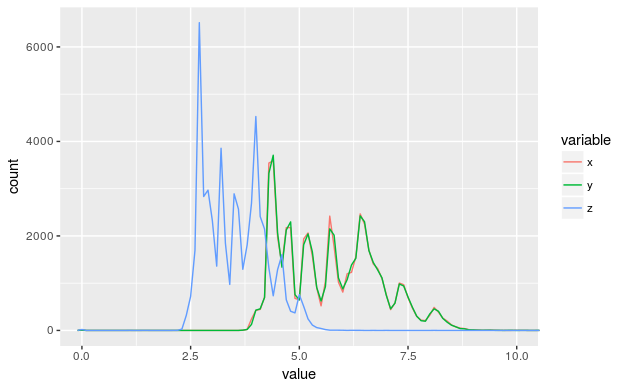

```r
newData <- melt(diamonds, measure.vars = c("x", "y", "z"))
ggplot(data = newData, mapping = aes(x = value, colour = variable)) +
    geom_freqpoly(binwidth = 0.1)+
    coord_cartesian(xlim = c(0, 10)) # to not see outliers
```

Notice how x and y follow each other very closely, i.e. these are very similar dimentions. But z is generally smaller. Can imaging length and width to be similar (x and y) and depth z to be different (smaller). x is length, y is width, and z is depth

### Q2)

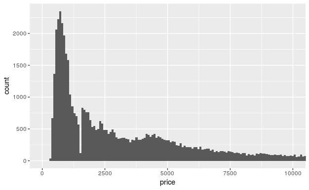

```r
ggplot(data = diamonds) +
    geom_histogram(mapping = aes(x = price), binwidth = 80)+
    coord_cartesian(xlim = c(0, 10000))
```

We see a large bumb in the data at low price, as expected. But there is also a smaller bump at around 4000, not sure why. Also we see some data missing at price=1500.

### Q3)

How many diamonds at 0.99 carat?

```r
diamonds %>%
count(carat == 0.99) # TRUE    23
```

| carat == 0.99 | n |
| --- | --- |
| FALSE | 53917 |
| TRUE | 23 |

How many diamonds at 1 carat?

```r
diamonds %>%
    count(carat == 1.00)# TRUE  1558
```

| carat == 1 | n |
| --- | --- |
| FALSE | 52382 |
| TRUE | 1558 |

The difference is perhaps caused by rounding up numbers.

### Q4)

IMPORTANT: Compare `coord_cartesian()` vs `xlim()` or `ylim()` when zooming in on a histogram. Note: Use `xlim()` and `ylim()` functions to throw away data outside the limits

## 7.4.1 Exercises - Missing values

### Q1)

What happens to missing values in a histogram/bar chart? Why?

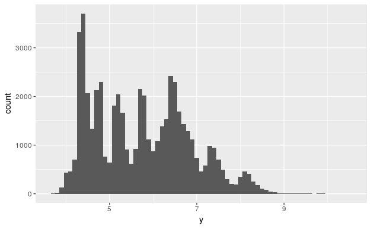

```r
diamonds2 <- diamonds %>% # change unusual values to NA
    mutate(y = ifelse(y < 3 | y > 20, NA, y))
ggplot(data = diamonds2) +
    geom_histogram(mapping = aes(x = y), binwidth = 0.1)
```

You get a Warning message, these rows are not counted.

In `geom_bar`, NA is treated as another category.

### Q2)

IMPORTANT: The option `na.rm = TRUE` in `mean()` and `sum()` removes the `NA`s from the calculation, otherwise `NA` would be returned.

## 7.5.1.1 Exercises - A categorical and continuous variable

### Q1)

Visualisation of the departure times of cancelled vs. non-cancelled flights. Here I am using a density plot to compare the distributions.

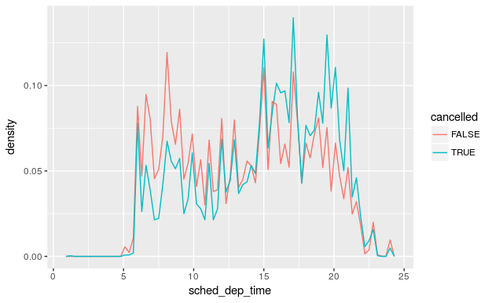

```r
nycflights13::flights %>%
    mutate(
        cancelled = is.na(dep_time),
        sched_hour = sched_dep_time %/% 100,
        sched_min = sched_dep_time %% 100,
        sched_dep_time = sched_hour + sched_min / 60
    ) %>%
    ggplot(mapping = aes(x = sched_dep_time,  y = ..density..)) +
    geom_freqpoly(mapping = aes(colour = cancelled), binwidth = 0.3)
```

Plotting density is much more informative. Can see a clear pattern.

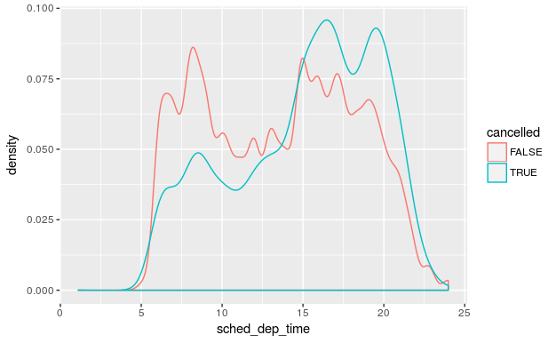

```r
nycflights13::flights %>%
    mutate(
        cancelled = is.na(dep_time), # TRUE or FALSE variable
        sched_hour = sched_dep_time %/% 100,
        sched_min = sched_dep_time %% 100,
        sched_dep_time = sched_hour + sched_min / 60 # in hours
    ) %>%
    ggplot(mapping = aes(sched_dep_time)) +
    geom_density(mapping = aes(colour = cancelled))
```

But perhaps a box plot is more illuminating

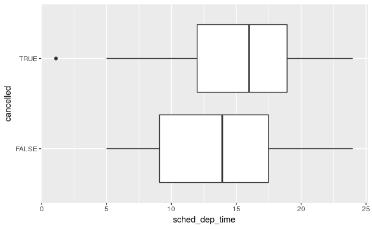

```r
nycflights13::flights %>%
    mutate(
        cancelled = is.na(dep_time),
        sched_hour = sched_dep_time %/% 100,
        sched_min = sched_dep_time %% 100,
        sched_dep_time = sched_hour + sched_min / 60
    ) %>%
    ggplot(mapping = aes(x = cancelled, y = sched_dep_time)) +
    geom_boxplot() +
    coord_flip()
```

### Q2)

What variable in the diamonds dataset is most important for predicting the price of a diamond?

Here let’s see all the co-relationships: the categorical variables in this dataset are: cut color clarity

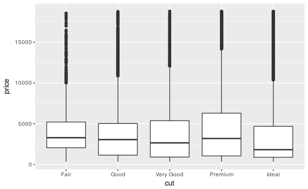

```r
ggplot(diamonds, aes(x = cut, y = price)) +
    geom_boxplot()
```

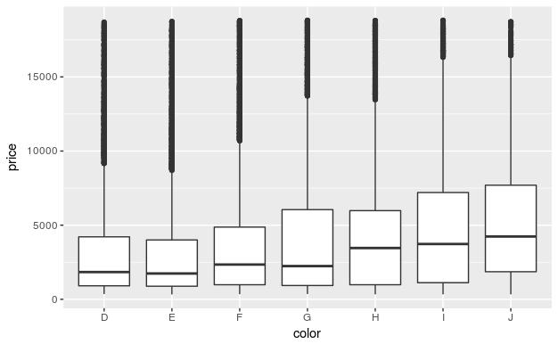

```r
ggplot(diamonds, aes(x = color, y = price)) +
    geom_boxplot()
```

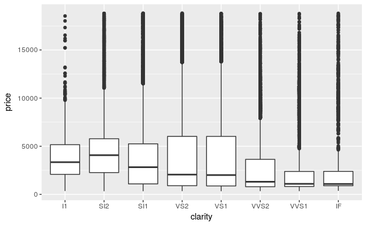

```r
ggplot(diamonds, aes(x = clarity, y = price)) +
    geom_boxplot()
```

Looks like maybe price varies most with color, but this is not totally clear. Not sure how to answer this question. I think perhaps carat predicts price best…

### Q3)

For horizontal boxplots instead of:

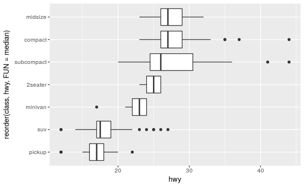

```r
ggplot(data = mpg) +
    geom_boxplot(mapping = aes(x = reorder(class, hwy, FUN = median), y = hwy)) +
    coord_flip()
```

do:

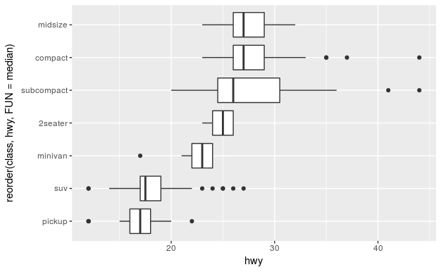

```r
ggplot(data = mpg) +
    geom_boxploth(mapping = aes(y = reorder(class, hwy, FUN = median), x = hwy))
```

### Q4)

For large data, use `lvplot` package and `geom_lv()` to display distributions of price vs cut:

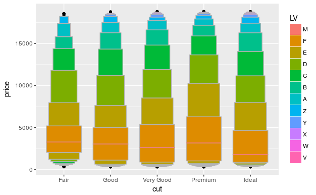

```r
ggplot(data = diamonds, mapping = aes(x = cut, y = price)) +
    geom_lv(aes(fill=..LV..))
```

### Q5)

Compare `geom_violin()` with a facetted `geom_histogram()`, or a coloured `geom_freqpoly()`:

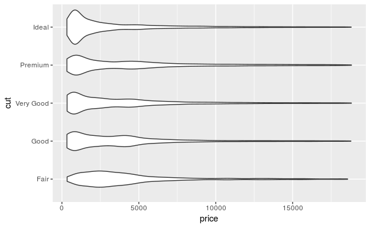

```r
ggplot(data = diamonds, mapping = aes(x = cut, y = price)) +
    geom_violin() +
    coord_flip()
```

This is not so interesting. Violin plots are quite good to compare distributions

### Q6)

For small dataset, it’s sometimes useful to use `geom_jitter()` to see the relationship between a continuous and categorical variable. Package `ggbeeswarm` for similar method for small datasets.

I didn’t look into this too much.

## 7.5.2.1 Exercises - Two categorical variables

### Q1)

Rescale the count dataset to more clearly show the distribution of cut within colour:

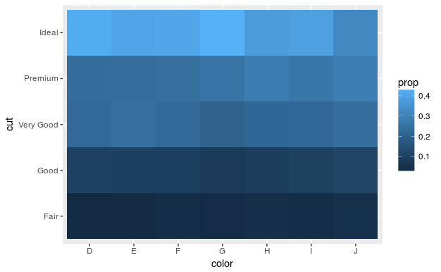

```r
diamonds %>%
    count(color, cut) %>%
    group_by(color) %>%
    mutate(sum = sum(n),
           prop = n/sum(n)) %>% # proportion in each cut for each color group
    ggplot(mapping = aes(x = color, y = cut)) +
    geom_tile(mapping = aes(fill = prop))
```

For the distribution of colour within cut, `group_by(cut)`

### Q2)

Explore how average flight delays vary by destination and month of year.

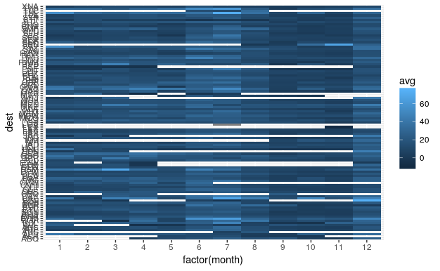

```r
flights %>%
    group_by(dest, month) %>%
    summarise(avg = mean(dep_delay, na.rm = T)) %>%
    ggplot(aes(factor(month), dest)) +
    geom_tile(mapping = aes(fill = avg))
```

This is a mess and hard to see any pattern. Lots of months for certain dest that have no data, i.e no flights this make the plot hard to read:

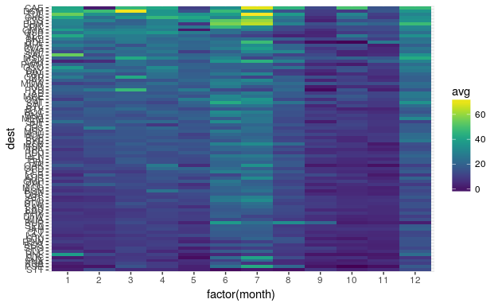

```r
flights %>%
    group_by(dest, month) %>%
    summarise(avg = mean(dep_delay, na.rm = T)) %>%
    group_by(dest) %>%
    filter(n() == 12) %>% #only destinations where all 12 months have data
    ungroup() %>%
    mutate(dest = fct_reorder(dest, avg)) %>% #re-ordering data
    ggplot(mapping = aes(x = factor(month), y = dest)) +
    geom_tile(mapping = aes(fill = avg)) +
    scale_fill_viridis() # better colour range
```

## 7.5.3.1 Exercises - Two continuous variables

### Q1)

Frequency poly, of Price, broken up into groups of carat

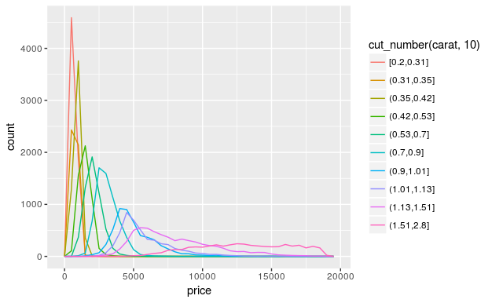

```r
ggplot(filter(diamonds, carat < 3), aes(price, colour = cut_number(carat, 10))) +
    geom_freqpoly(binwidth = 500)
```

with `cut_number`, creat 10 equally-sized carat bins. You can control the number of polygons, but the ranges of carat values can vary quite a bit.

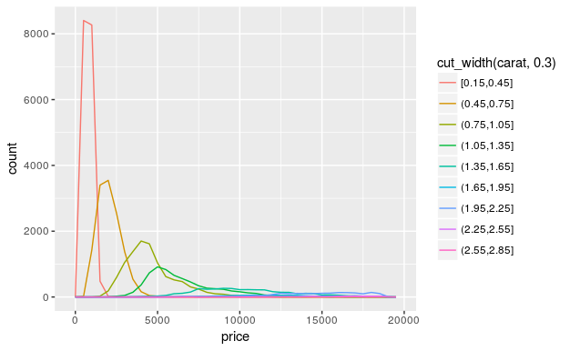

```r
ggplot(filter(diamonds, carat < 3), aes(price, colour = cut_width(carat, 0.3))) +
    geom_freqpoly(binwidth = 500)
```

with `cut_width`, creat bins of certain width, the ranges of carat values are the same, but the number of obs per bin can vary quite a bit.

### Q2)

Visualise the distribution of carat, partitioned by price.

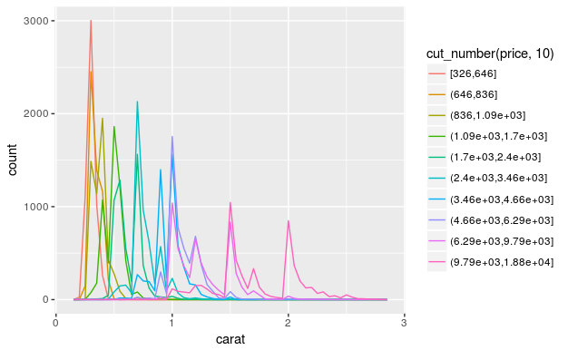

```r
ggplot(data = filter(diamonds, carat < 3),
       mapping = aes(x = carat, colour = cut_number(price, 10))) +
    geom_freqpoly(binwidth = 0.05)
```

### Q3)

Price distribution of diamonds by size

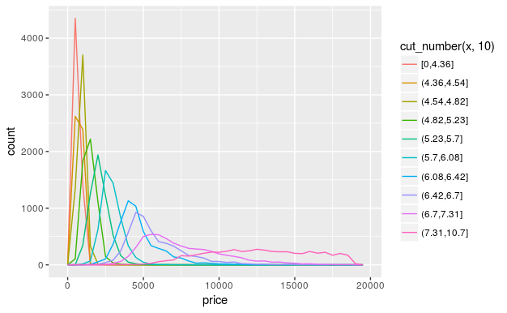

```r
ggplot(diamonds, aes(price, colour = cut_number(x, 10))) +
    geom_freqpoly(binwidth = 500)
```

as the price increases, the distributions becomes more spread out. Perhaps this is surprising, why would the price vary more for larger diamonds. Other factors become more important for larger diamonds, e.g. `cut` and `colour` and `clarity` perhaps.

### Q4)

Visualise the combined distribution of `cut`, `carat`, and `price`.

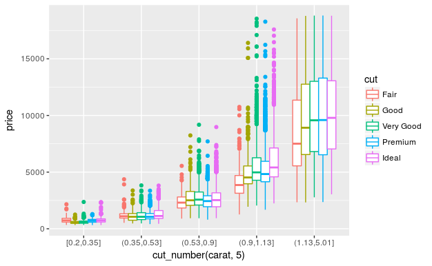

```r
ggplot(diamonds, aes(cut_number(carat, 5), price, color = cut)) +
    geom_boxplot()
```

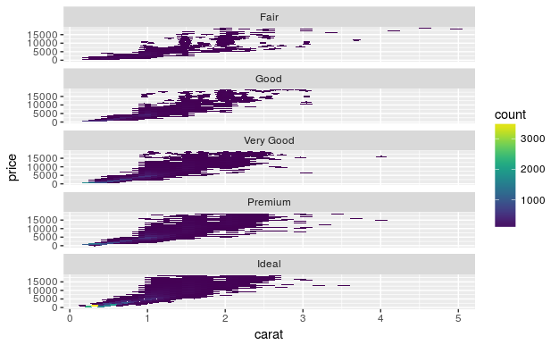

```r
ggplot(diamonds, aes(x = carat, y = price)) +
    geom_hex() +
    scale_fill_viridis() +
    facet_wrap(~ cut, ncol = 1)
```